# WRCC Data Extremes 2021

Jonathan Callahan

2022-09-07

This mini-report takes a look at the data values from USFS deployed temporary monitors whose data is handled by the Western Regional Climate Center (WRCC) at the Desert Research Institute (DRI).

We compare data values from these monitors against the AirNow default QC chcecks for:

- Max severe (invalid) range: 175 ug/m3
- Rate of change: 40 ug/m3

# WRCC Data

During the fall of 2021, 49 monitors were deployed whose data was transmitted via GOES satellite to WRCC and subsequently processed by AirFire data ingest scripts. The following plots show the values of PM2.5 for a three month period when wildfire smoke was impacting communities.

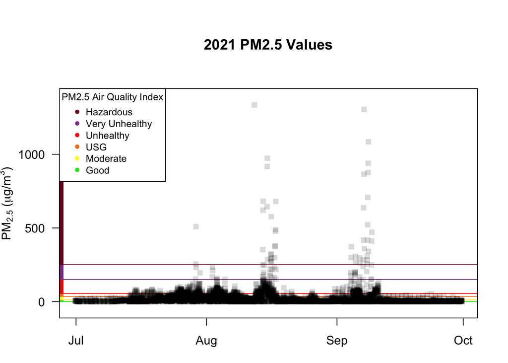

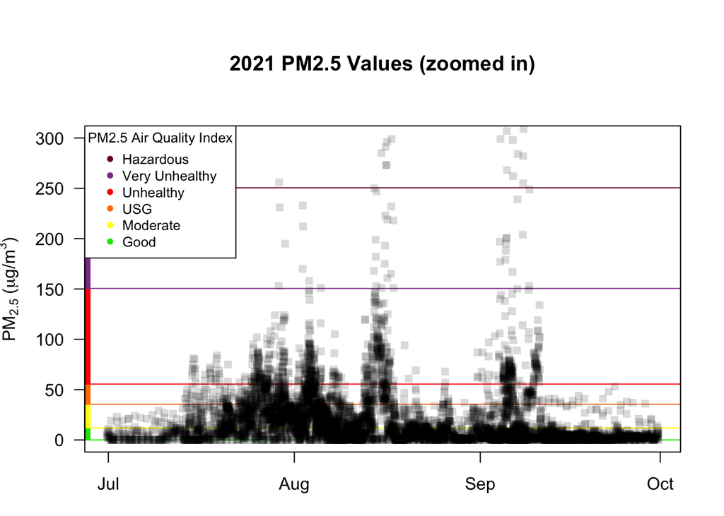

## High Value Cutoff = 175

AirNow uses automated QC to invalidate any values above a “Max Severe” level. The default level for this high value cutoff is 175 ug/m3.

Below we see two histograms, one with all of the values below the default “high value” cutoff of 175 ug/m3 and a second one with all the values above the cutoff.

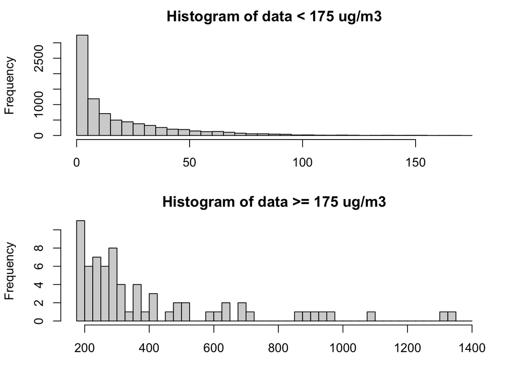

**Monitors with the highest values**

Three monitors in this time period had hourly PM2.5 values above 175 ug/m3. Of the three, only the monitor named “Smoke USFS R1-52” appears to have an *invalid* high value while the monitor named “Smoke USFS 3016” has many valid high values.

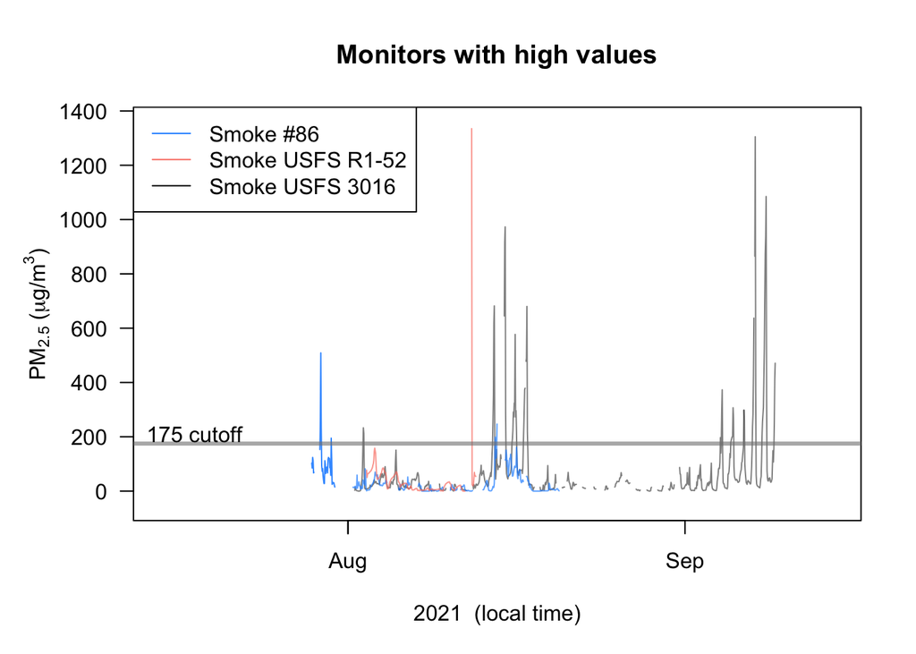

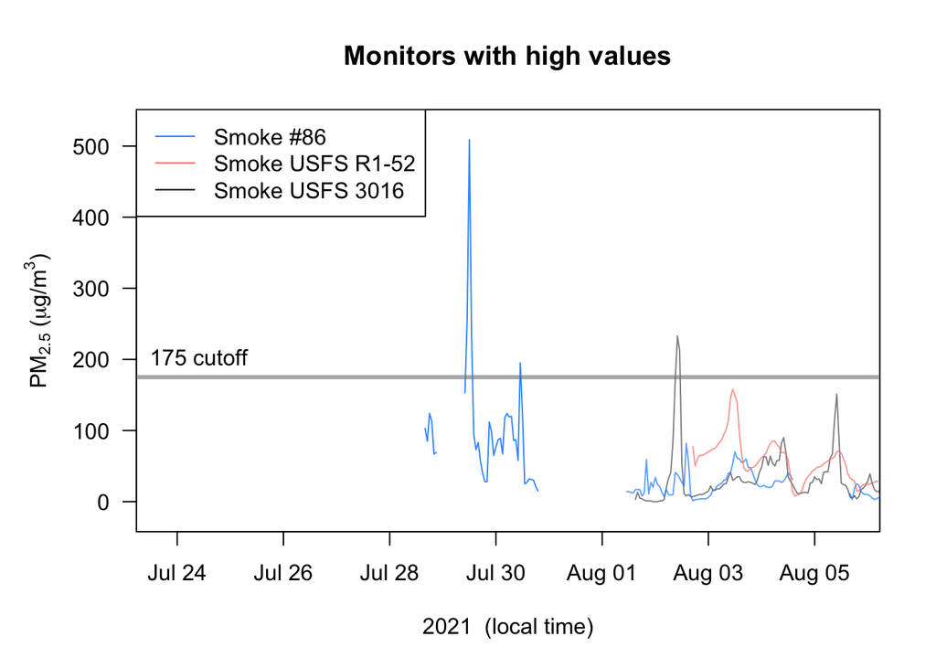

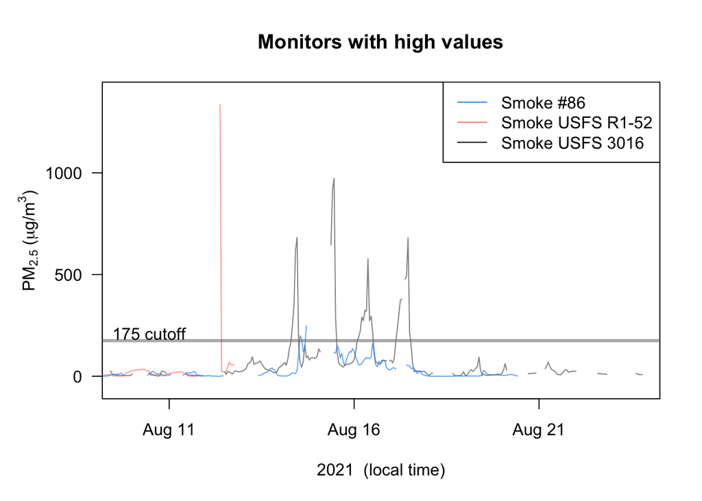

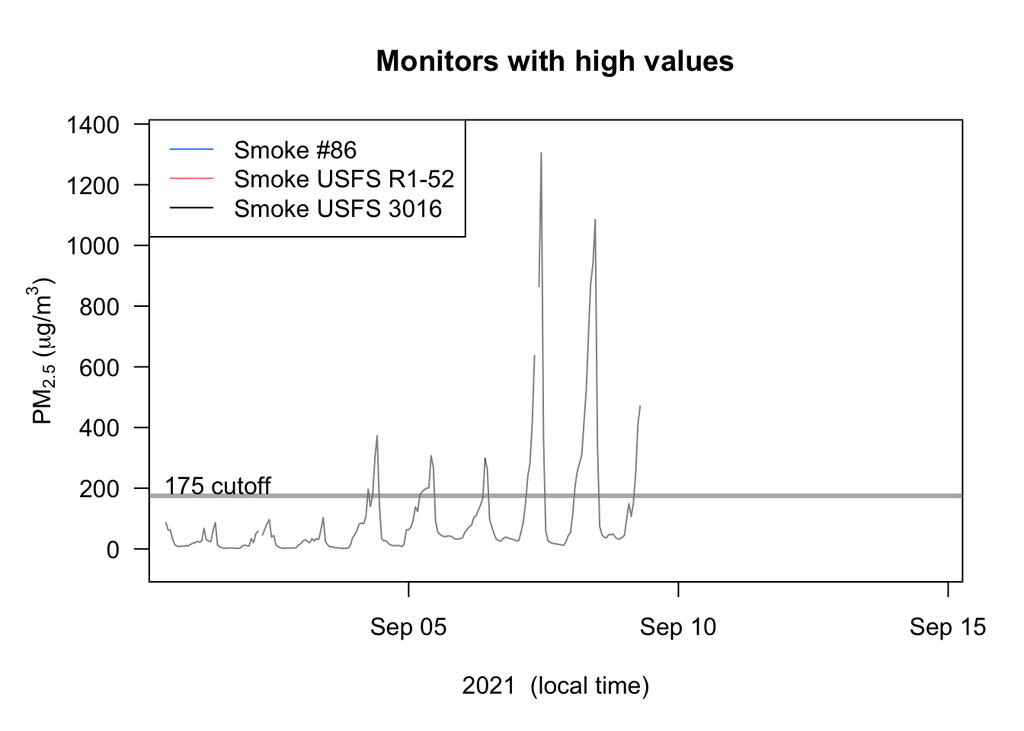

## Rate of Change Cutoff = 40 ug/m3/hr

AirNow QC also applies a rate-of-change cutoff of 40 ug/m3/hr to flag suspect data. This cutoff may also be too low for monitors deployed near wildfires.

The histograms of rate-of-change for this time period are below. There is a reasonable sprinkling of rate-of-change values above 40 ug/m3/hr associated with 7 separate monitors.

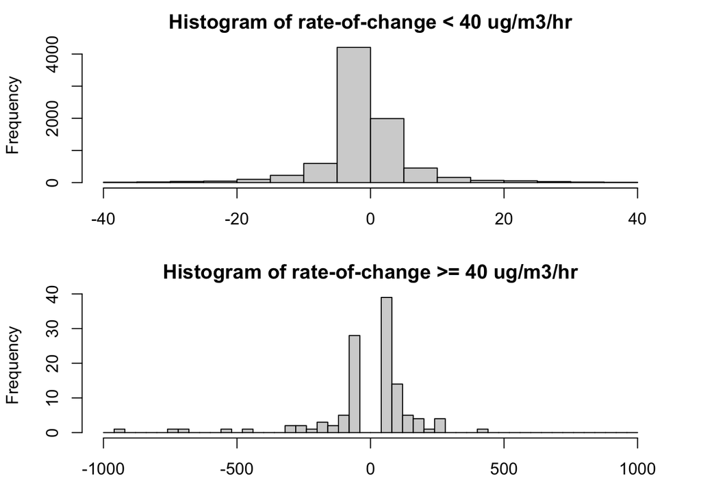

**Monitors with high rate-of-change values**

We can view those high rate-of-change values in context with the following series of timeseries plots. For the vast majority of cases, these high rate-of-change values are associated with smoke in an environment with strong diurnal variation in PM2.5 levels. All of these values in red are associated with high rate-of-change and almost all appear to be valid.

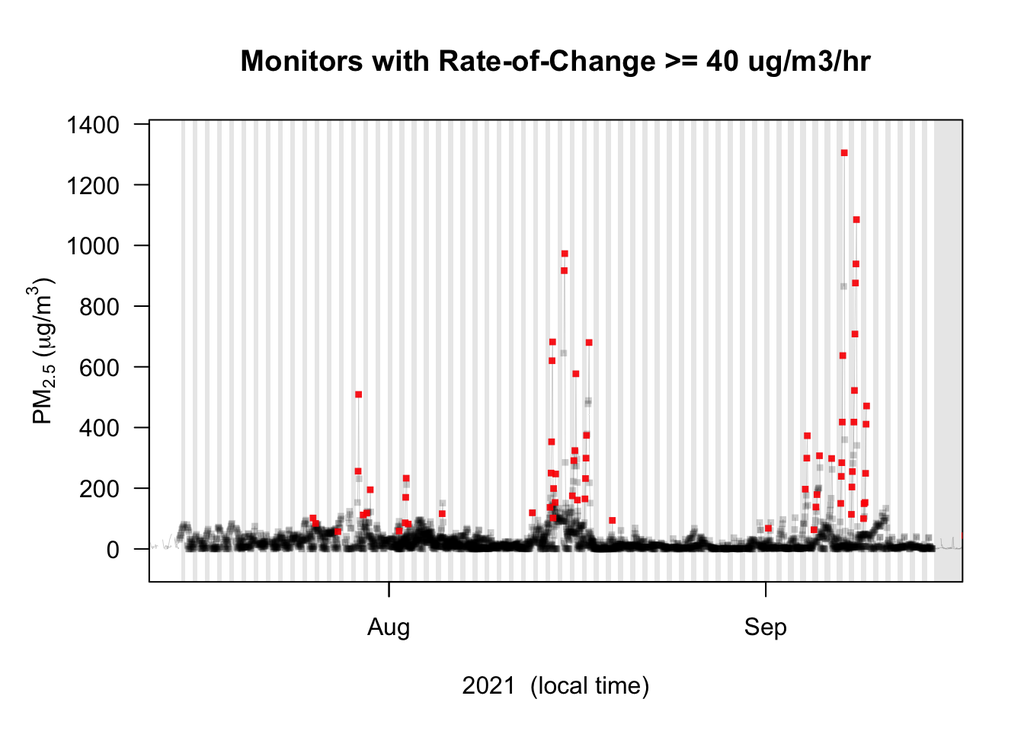

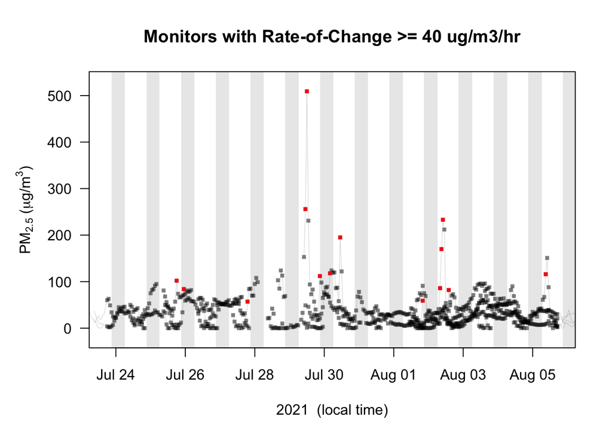

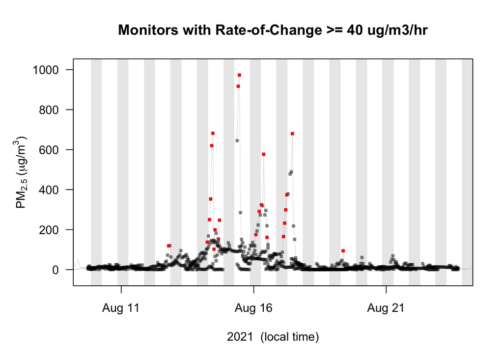

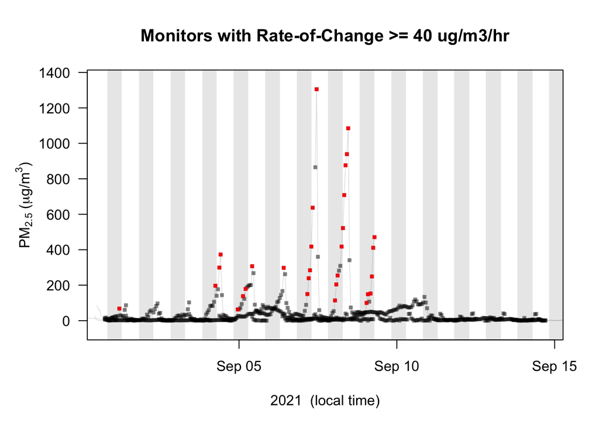